# Synaptome Statistics: Report June 2017

2017-06-27

# 1 Synaptome Statistics: Notes

Putative synapse locations have been detected in K15 with Forrest’s synapse detection algorithm and in W with Anish’s synapse detection algorithm. For each feature channel (Synapsin, VGlut, psd95, etc.) an 11x11x11 cube is extracted around each each putative synapse location and the voxel values are summed, creating a feature vector of length (number of channels). This gives us an $n \times d$ matrix, where the $n$ rows correspond to putative synapses and the $d$ columns correspond to the summed immunoflorescence in each channel.

## 1.1 Clustering

We have implemented our own Hierarchical Mclust function by augmenting Mclust. In the course of exploring we used the full suite of models available in [mclustModelNames p. 88](https://cran.r-project.org/web/packages/mclust/mclust.pdf)

## 1.2 MEDA Run on Z-scored data

### 1.2.1 1-d Heatmap

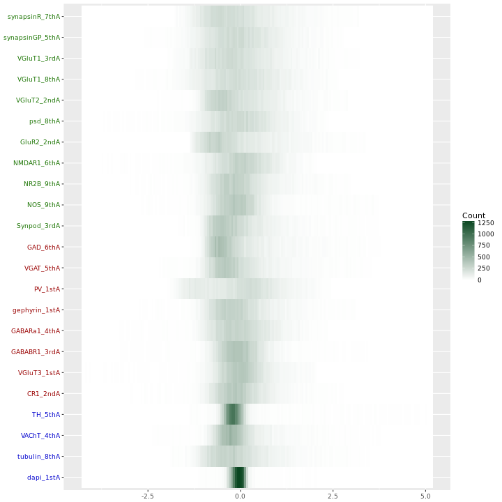

### 1.2.2 Location plots

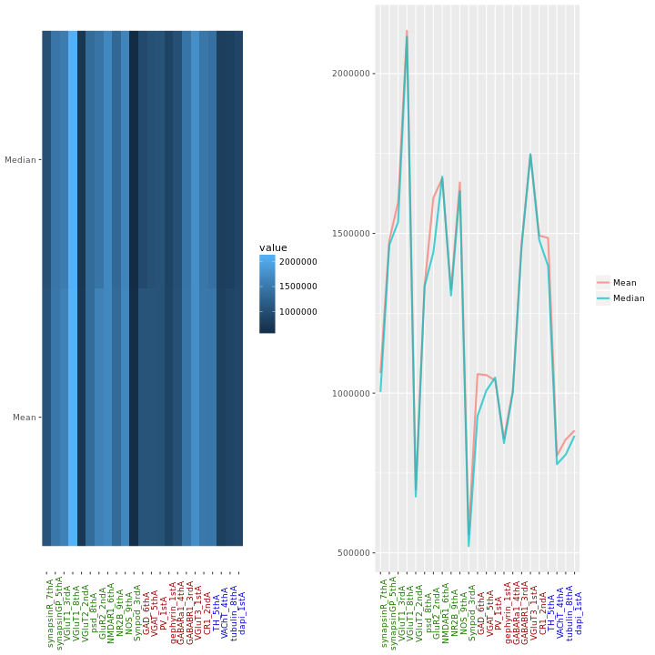

### 1.2.3 Outliers as given by randomForest

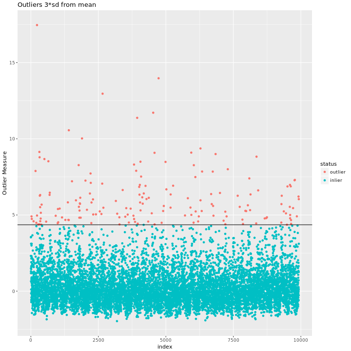

### 1.2.4 Correlation Matrix

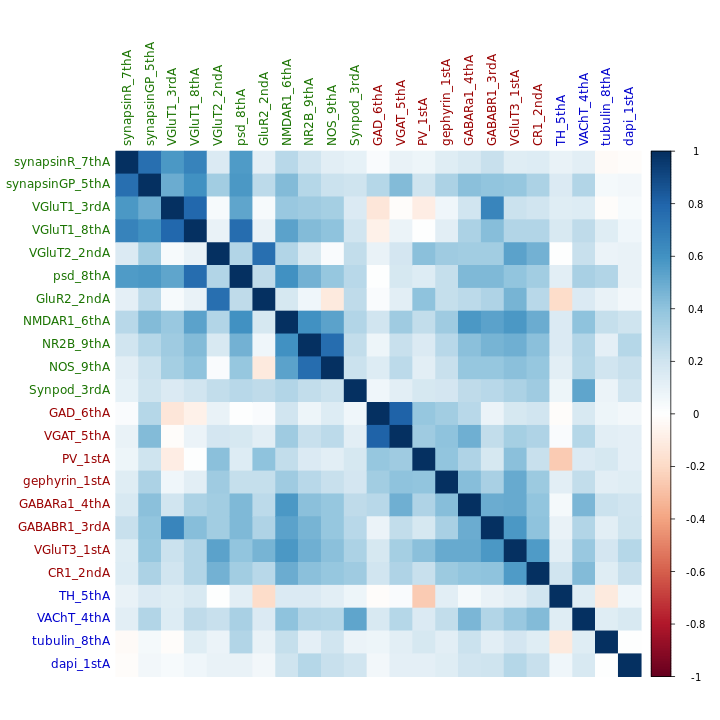

### 1.2.5 Cumulative Variance with Elbows

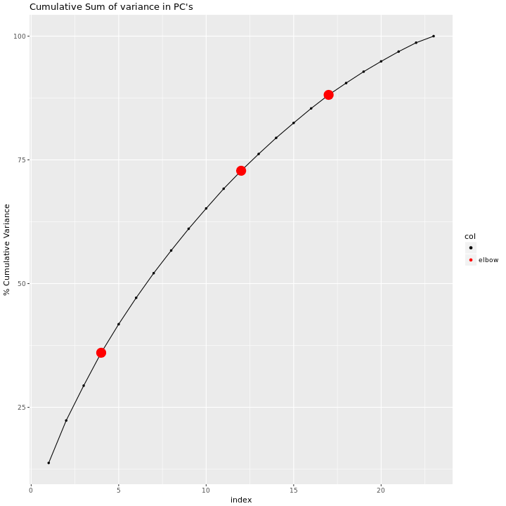

### 1.2.6 Paired Hex-binned plot

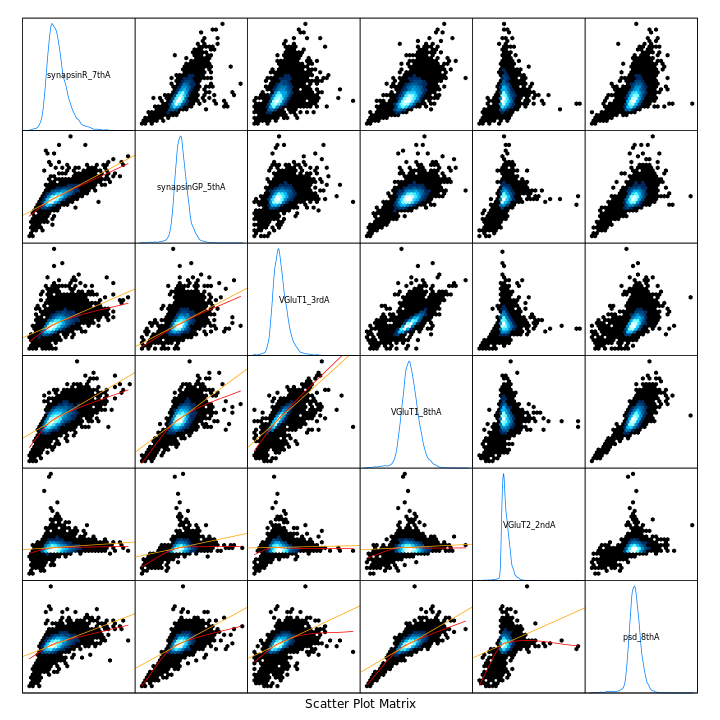

### 1.2.7 Hierarchical GMM Classifications

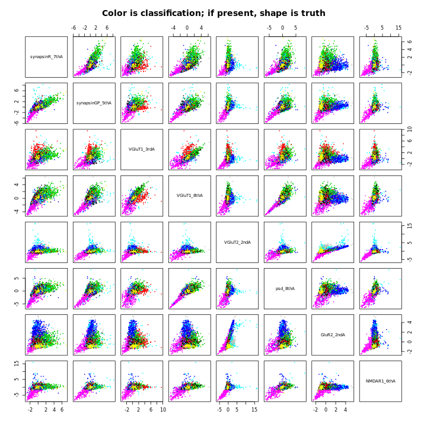

### 1.2.8 Hierarchical GMM Dendrogram

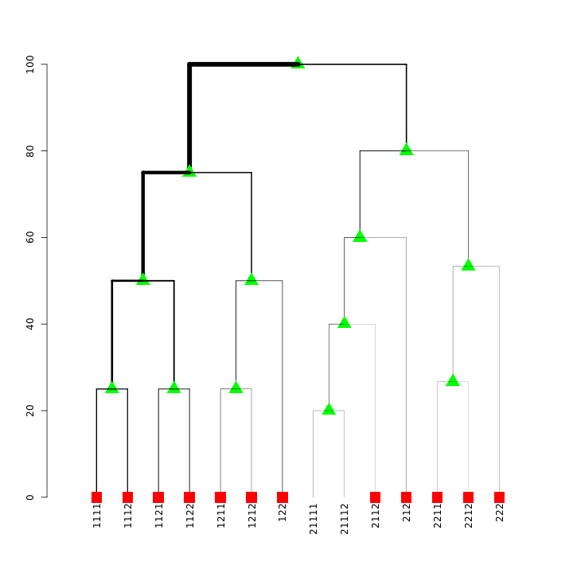

### 1.2.9 Stacked Cluster Means plot

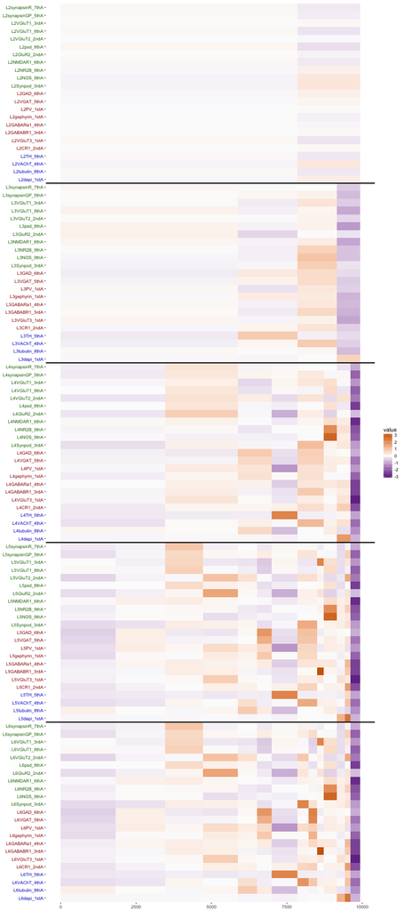

### 1.2.10 Cluster Means

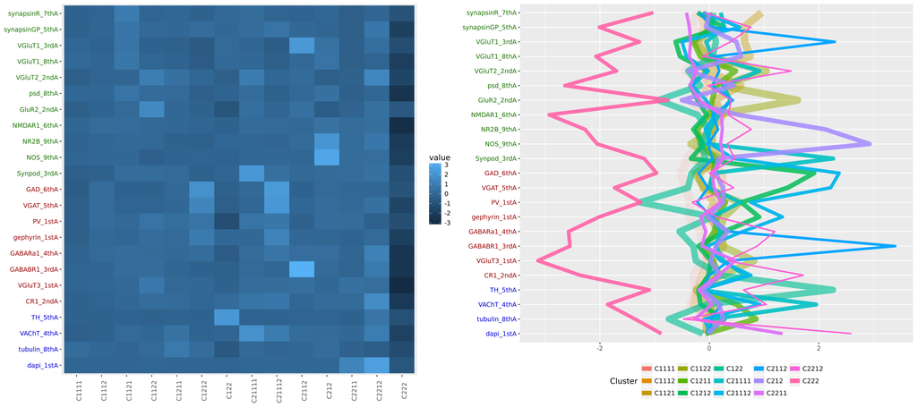

# 2 Cluster Synaptograms

The below table contains links to synaptograms (syn*) from each cluster as given above with a corresponding ndviz link (ndv*). The 5 synapses with feature vectors closest to their cluster mean were chosen as representatives.

[output not shown]

### 2.0.1 The following is a synaptogram from cluster C1121 @ x=770, y=6473, z=17

And as you can see, both Synapsin channels and both VGlut1 channels are “hot” which match the cluster mean as given above.

[figure not shown]